# Squeezing R with awesome packages

Adrian Lopez Garcia

11/12/2019

# PART II: GGPLOT2

> [OVERVIEW](https://ggplot2.tidyverse.org//)  
> [CHEATSHEET](https://github.com/rstudio/cheatsheets/blob/master/data-visualization-2.1.pdf)

## Ggplot2 basics:

[figure not shown]

`ggplot2` is a system for declaratively creating graphics. Providing the data, you tell `ggplot2` how to map variables to **aesthetics**, what graphical primitives to use, and it takes care of the details. The basic functioning includes these steps:

1. Start the plot with `ggplot()` function, supplying a dataset and an aesthetic mapping with `aes()`.
2. Add layers to plot your variables with different ways, like dots (`geom_point()`), boxplots (`geom_boxplot()`), bars (`geom_bars()`) or density plots (`geom_density()`).
3. Add coordinates systems, for example with `coord_flip()`.
4. Add customization layers:
   - Axes scales or limits: `scale_x_()` / `scale_y_()`, `xlim()` / `ylim()`.
   - Color scales: `scale_color_()` and `scale_fill_()` functions.
   - General plot customization: `theme()` function.
5. Add facetting specifications, `facet_grid()` and `facet_wrap()`.

This is a scheme of the general structure of a ggplot code.

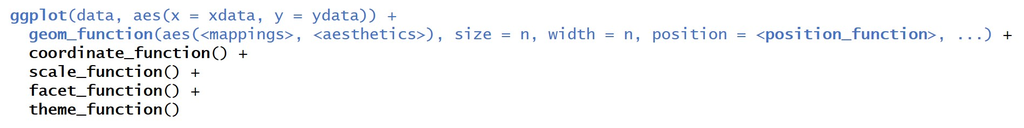

We will now provide multiple plot examples to deepen in the grammar and all the package possibilities.

### Basic structure:

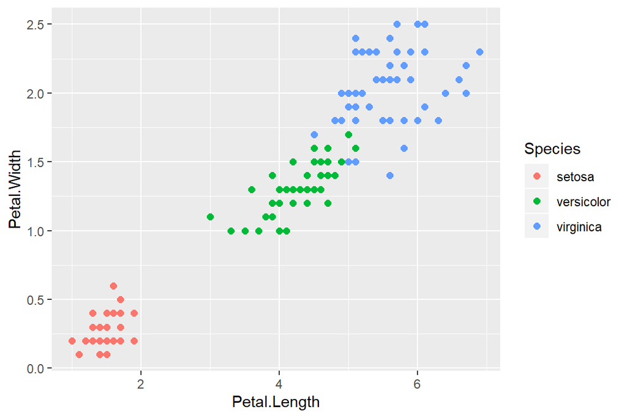

```r
data(iris)

ggplot(data = iris, aes(x = Petal.Length, y = Petal.Width, col = Species)) +
  geom_point(size = 2)
```

### Customization:

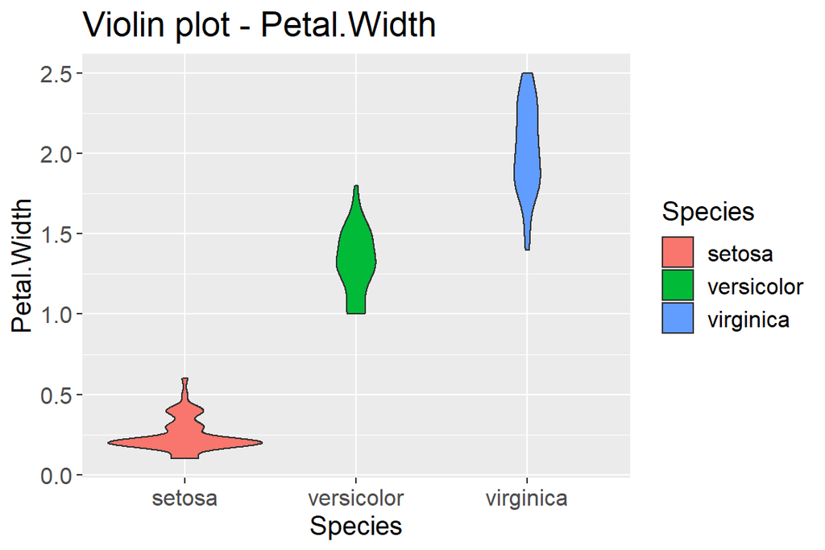

```r
ggplot(data = iris, aes(x = Species, y = Petal.Width)) +
  geom_violin(aes(fill = Species)) +
  ggtitle(label = "Violin plot - Petal.Width") +
  theme(plot.title = element_text(size = 18),
        legend.title = element_text(size = 14),
        legend.text = element_text(size = 12),
        axis.title = element_text(size = 14),
        axis.text = element_text(size = 12))
```

### Multiple layers:

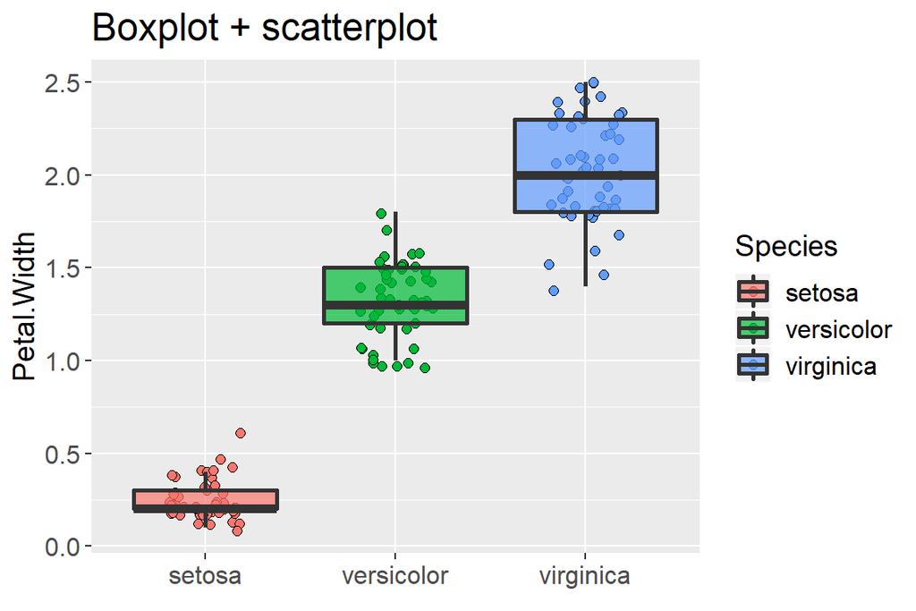

```r
irisplot <- ggplot(data = iris, aes(x = Species, y = Petal.Width)) +
  geom_jitter(aes(fill = Species), col = "black", size = 2, shape = 21, width = 0.2) +
  geom_boxplot(aes(fill = Species), alpha = 0.7, size = 1, outlier.shape = NA) +
  xlab(element_blank())

layer <- list(ggtitle(label = "Boxplot + scatterplot"),
              theme(plot.title = element_text(size = 18),
                    legend.title = element_text(size = 14),
                    legend.text = element_text(size = 12),
                    axis.title = element_text(size = 14),
                    axis.text = element_text(size = 12)))

irisplot + layer
```

### Density plots:

[figure not shown]

```r
data(diamonds)

diam0 <- ggplot(diamonds, aes(x = carat, fill = cut, col = cut)) +
  geom_density(alpha = 0.1) +
  ggtitle("Density plot")

diam1 <- ggplot(diamonds, aes(x = carat, fill = cut)) +
  geom_density(position = "stack") +
  ggtitle("Stacked Density plot")

diam2 <- ggplot(diamonds, aes(x = carat, fill = cut)) +
  geom_density(position = "fill") +
  ggtitle("Conditional Density plot")
```

### Faceting plots:

- `facet_grid()`: Useful for making 2-factors matrices.
- `facet_wrap()`: Creates partitions using one grouping variable.

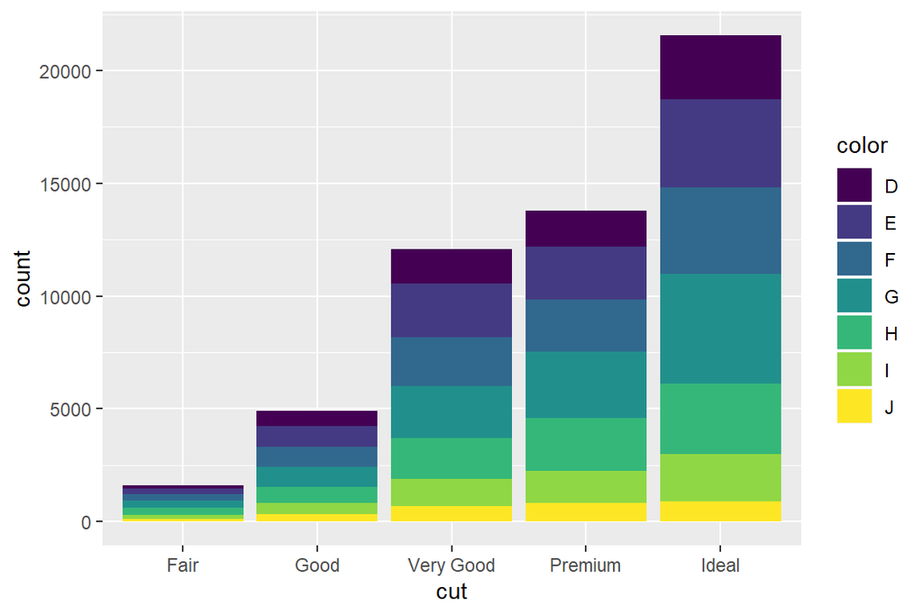

```r
ggplot(diamonds,aes(x = cut)) + geom_bar(aes(fill = color))
```

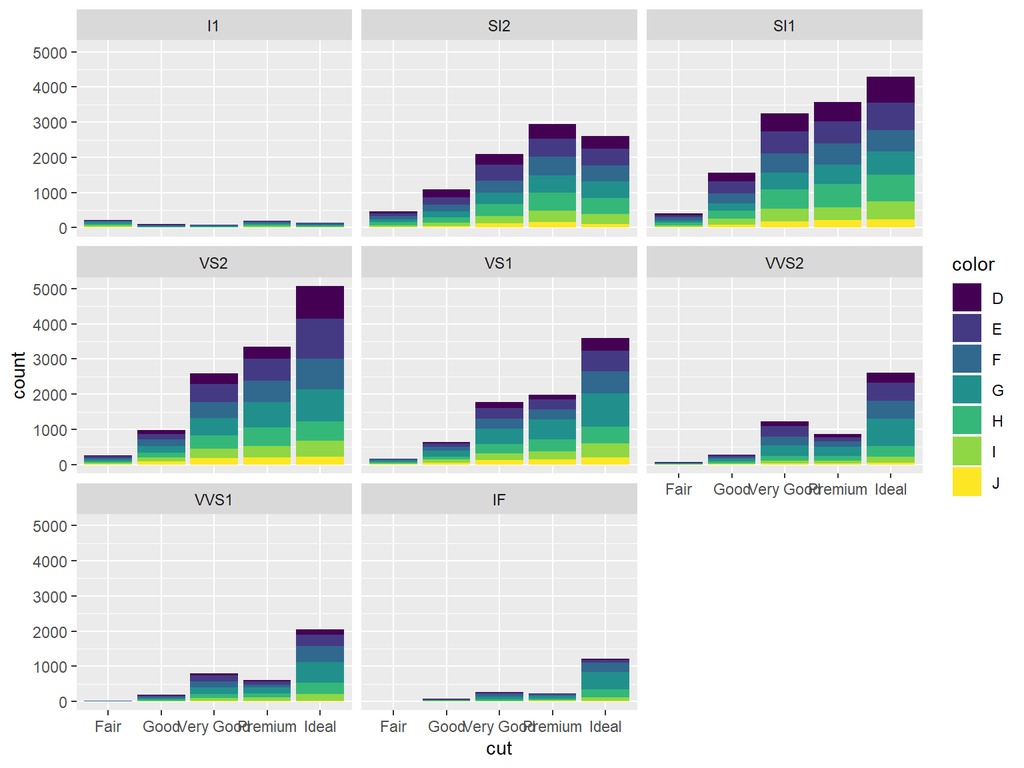

```r
ggplot(diamonds,aes(x = cut)) + geom_bar(aes(fill = color)) +
  facet_wrap( ~ clarity)
```

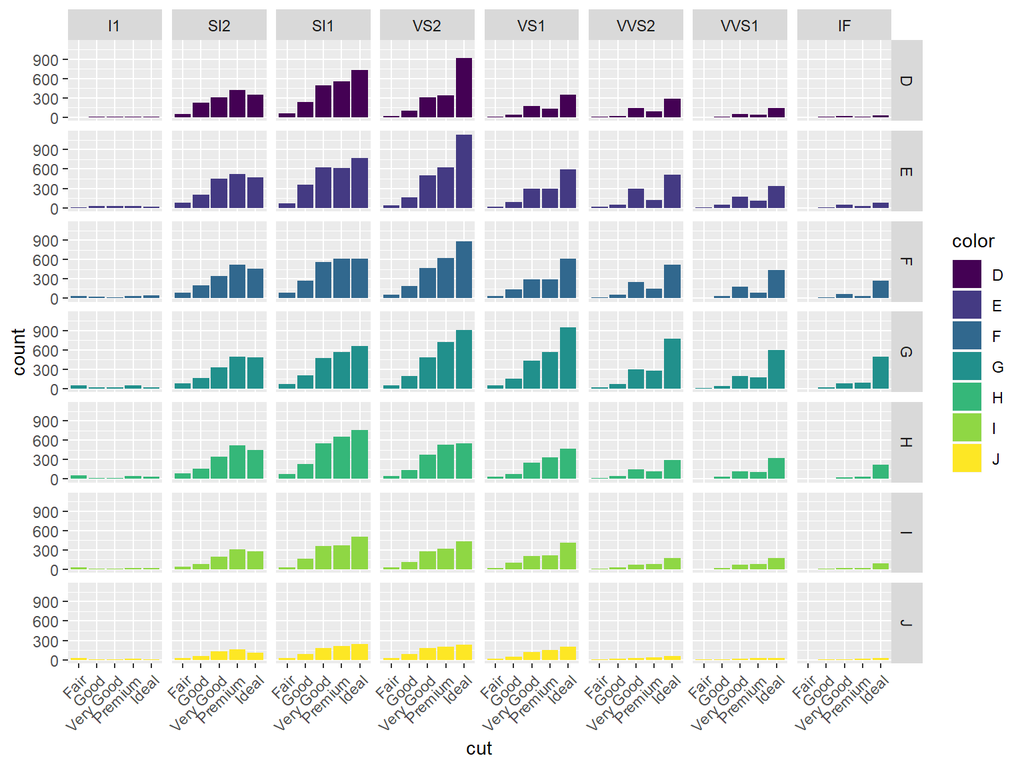

```r
ggplot(diamonds,aes(x = cut)) + geom_bar(aes(fill = color)) +
  facet_grid(color ~ clarity) +
  theme(axis.text.x = element_text(angle = 45, hjust = 1))
```

## Grid & GridExtra:

[figure not shown]

The `grid` package provides low-level functions to create **graphical objects** (aka **grobs**), and position them on a page in specific viewports. The `gtable` package introduced a higher-level layout scheme, arguably more amenable to user-level interaction. With the `arrangeGrob()`/`grid.arrange()` pair of functions, `gridExtra` builds upon gtable to arrange multiple grobs on a page.

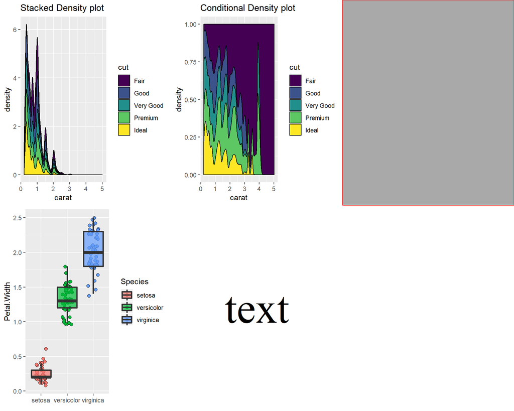

```r
library(grid); library(gridExtra)

r <- rectGrob(gp = gpar(fill = "darkgrey", col = "red"))
t <- textGrob("text", gp=gpar(fontfamily = "serif", cex=5))

grid.arrange(diam1, diam2, r, irisplot, t, ncol = 3, nrow = 2)
```

We can make really complex grids using the `layout_matrix` argument, including different sized grobs and even blank spaces.  
For example, if we have 9 different grobs:

```r
# Create a matrix layout:
hlay <- rbind(c(1,1,NA,2,3),
              c(1,1,NA,4,NA),
              c(NA,7,8,9,NA))
hlay
```

```
##      [,1] [,2] [,3] [,4] [,5]
## [1,]    1    1   NA    2    3
## [2,]    1    1   NA    4   NA
## [3,]   NA    7    8    9   NA
```

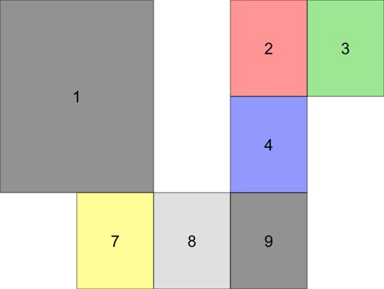

```r
# Print our 9 grobs:
grid.arrange(g1, g2, g3, g4, g5, g6, g7, g8, g9, layout_matrix = hlay)
```

We can also use `widths` and `heights` arguments for changing proportions of grobs.

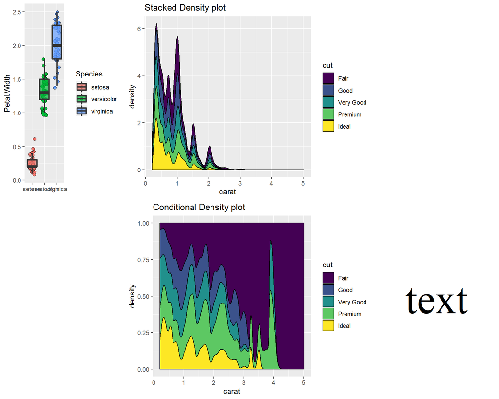

```r
# Using layout_matrix:
hlay <- rbind(c(1,2,2,NA),
              c(NA,3,3,4))

grid.arrange(irisplot, diam1, diam2, t, layout_matrix = hlay)
```

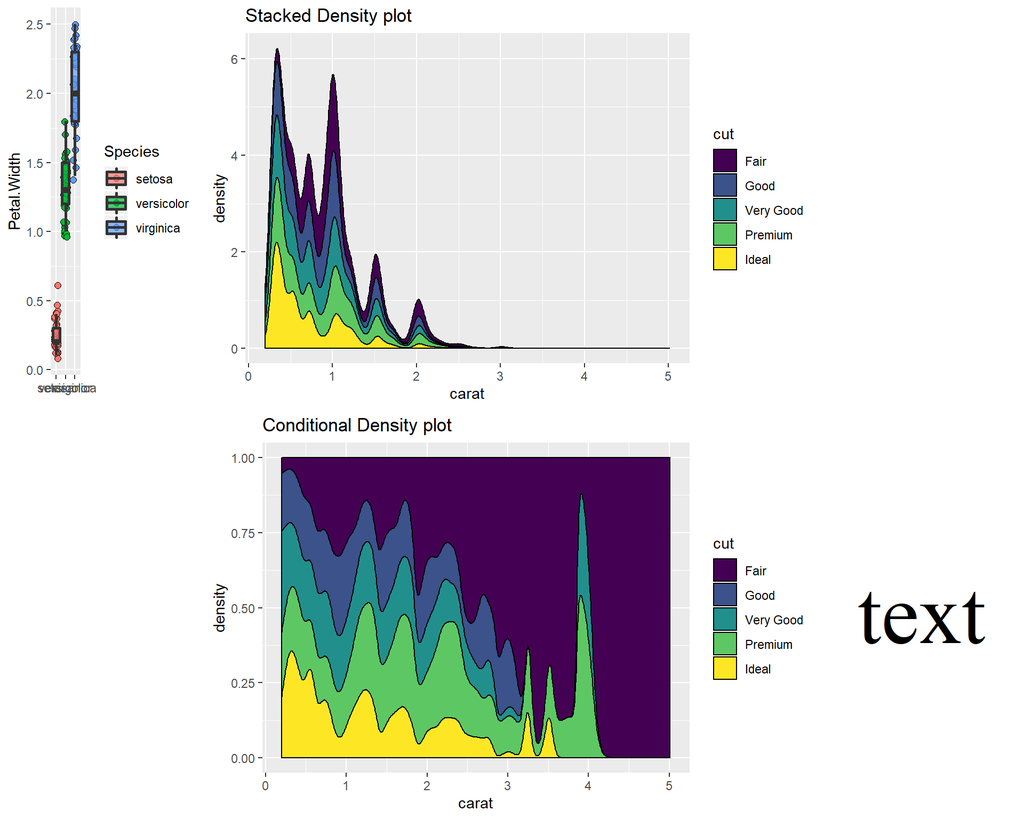

```r
# Using widths:
blank <- rectGrob(gp = gpar(fill = "white", col = "white"))

grid.arrange(irisplot, diam1, blank, blank, diam2, t, ncol = 3, nrow = 2, widths = c(1, 3, 1))
```

We have seen that `grid.arrange()` **draws** layouts on the device. If we want to **store** multiple complex grids for then drawing them (eg., combine it with new objects, form nested layouts…) we can use `arrangeGrob()`.

```r
# Create layout:o
lay <- rbind(c(1,1,1,2,3),
             c(1,1,1,4,5),
             c(6,7,8,9,9))
lay; t(lay)
```

```
##      [,1] [,2] [,3] [,4] [,5]
## [1,]    1    1    1    2    3
## [2,]    1    1    1    4    5
## [3,]    6    7    8    9    9
```

```
##      [,1] [,2] [,3]
## [1,]    1    1    6
## [2,]    1    1    7
## [3,]    1    1    8
## [4,]    2    4    9
## [5,]    3    5    9
```

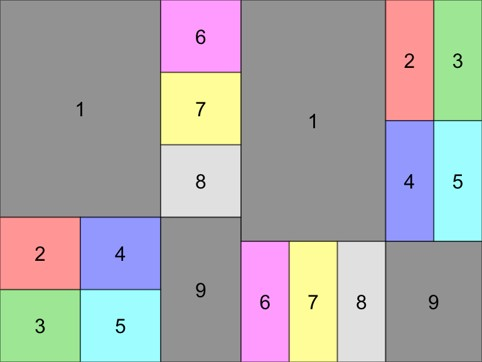

```r
# Store grobs and draw them:
sample_grobs <- list(g1, g2, g3, g4, g5, g6, g7, g8, g9)

g1 <- arrangeGrob(grobs = sample_grobs, layout_matrix = t(lay))
g2 <- arrangeGrob(grobs = sample_grobs, layout_matrix = lay)

grid.arrange(g1, g2, ncol = 2)
```

## Other GGplot allies:

[figure not shown]

### **GGally**:

> [Principal functions](https://ggobi.github.io/ggally/#full_diagnostic_plot_matrix_example)

Extension of `ggplot` adding several functions to reduce the complexity of combining geometric objects with transformed data. It includes multiple matrix-plotting functions, such as `ggmatrix()`, `ggpairs()`, `ggduo()` or `ggscatmat()`.

```
install.packages("GGally")
```

```r
library(GGally)
```

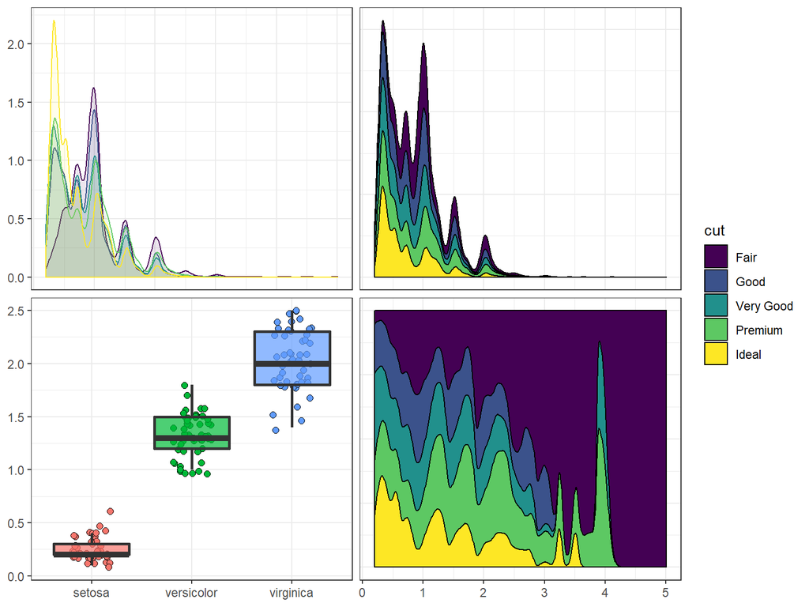

```r
gglist <- list(diam0, diam1, irisplot + layer, diam2)

ggmatrix(gglist, nrow = 2, ncol = 2, legend = c(2,2)) + theme_bw()
```

Unfortunately, `ggmatrix()` is not useful for independent layouts, as `gridExtra` was. It is more useful for plotting different plot types coming from the **same dataset** (similarly to faceting). Next functions are clear examples of this:o

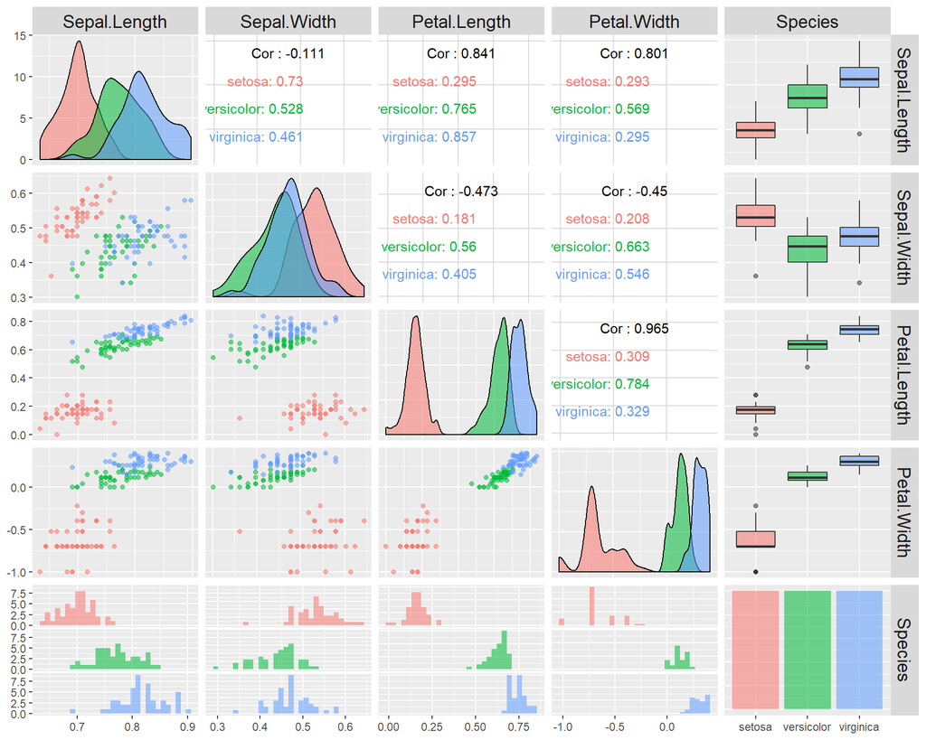

```r
iris %>% mutate_if(is.numeric, log10) %>%
  ggpairs(aes(colour = Species, alpha = 0.4)) +
  theme(strip.text.x = element_text(size = 14),
        strip.text.y = element_text(size = 14))
```

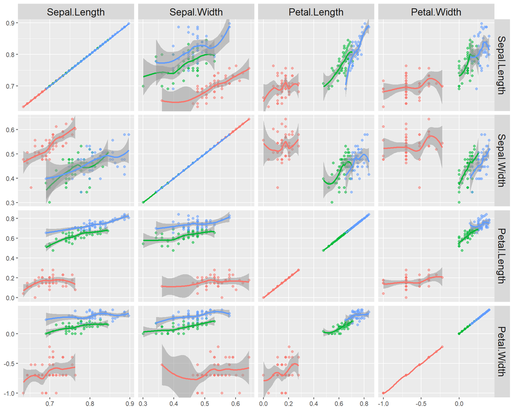

```r
iris %>% mutate_if(is.numeric, log10) %>%
  ggduo(columnsX = 1:4, columnsY = 1:4, aes(colour = Species, alpha = 0.4)) +
  theme(strip.text.x = element_text(size = 14),
        strip.text.y = element_text(size = 14))
```

### **Palette packages**:

> [R color reference sheet](http://bc.bojanorama.pl/wp-content/uploads/2013/04/rcolorsheet.pdf)  
> [R color palettes](https://www.datanovia.com/en/blog/top-r-color-palettes-to-know-for-great-data-visualization/#grey-color-palettes)

#### Package viridis

```r
# Install
install.packages("viridis")
```

```r
library(viridis)
```

The viridis package contains four sequential color scales: “Viridis” (the primary choice) and three alternatives with similar properties (“magma”, “plasma”, and “inferno”).

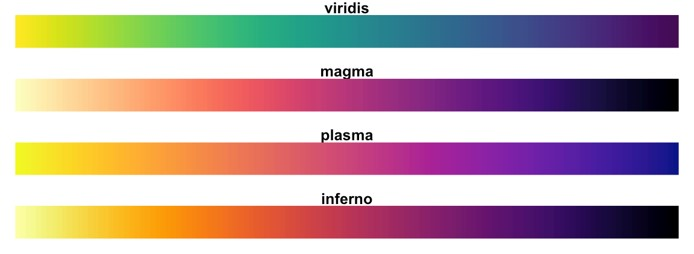

The Key functions are:

- `scale_color_viridis()`: Replaces `ggplot2::scale_color_manual()`.
- `scale_fill_viridis()`: Replaces `ggplot2::scale_fill_manual()`.
- `viridis(n)`, `magma(n)`, `inferno(n)` and `plasma(n)`: Generate color palettes for base plot, where n is the number of colors to returns.

#### Package RColorBrewer

```r
# Install
install.packages("RColorBrewer")
```

```r
library(RColorBrewer)
```

The RColorBrewer palettes can be displayed using this function:

```r
display.brewer.all()
```

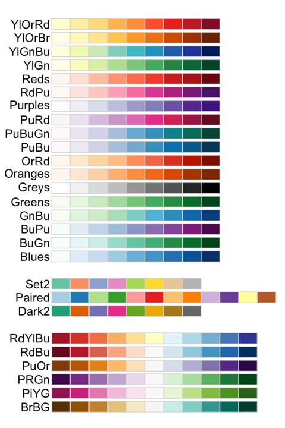

The Key functions are:

- `brewer.pal(n, name)`: Return the hexadecimal color specification.
- `display.brewer.pal(n, name)`: Display a single RColorBrewer palette by specifying its name.

```r
brewer.pal(6, "Dark2")
```

```
## [1] "#1B9E77" "#D95F02" "#7570B3" "#E7298A" "#66A61E" "#E6AB02"
```

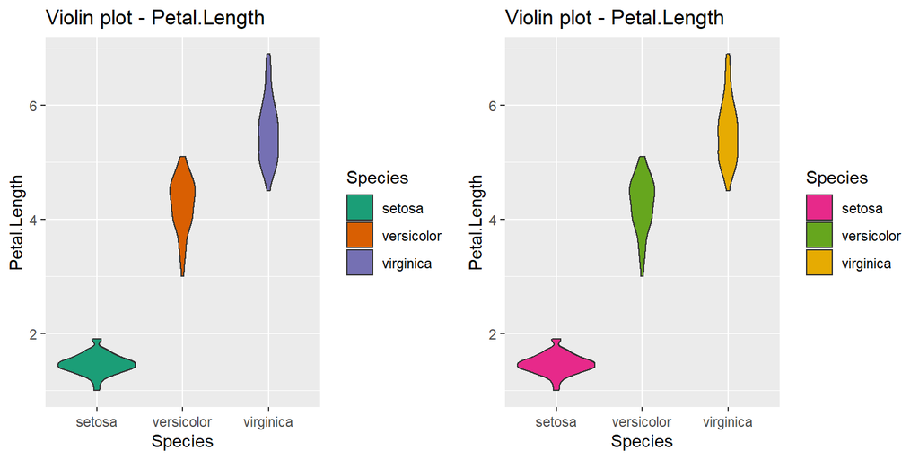

```r
gridExtra::grid.arrange(
  ggplot(data = iris, aes(x = Species, y = Petal.Length)) +
    geom_violin(aes(fill = Species)) +
    ggtitle(label = "Violin plot - Petal.Length") +
    scale_fill_brewer(palette = "Dark2"),
  ggplot(data = iris, aes(x = Species, y = Petal.Length)) +
    geom_violin(aes(fill = Species)) +
    ggtitle(label = "Violin plot - Petal.Length") +
    scale_fill_manual(values = brewer.pal(6, "Dark2")[4:6]),
  ncol = 2)
```

#### Package ggsci

The R package `ggsci` contains a collection of high-quality color palettes inspired by colors used in scientific journals, data visualization libraries, and more.

The color palettes are provided as ggplot2 scale functions. Some examples:

- `scale_color_npg()` & `scale_fill_npg()`: Nature Publishing Group color palettes.
- `scale_color_aaas()` & `scale_fill_aaas()`: American Association for the Advancement of Science color palettes.
- `scale_color_lancet()` & `scale_fill_lancet()`: Lancet journal color palettes.
- `scale_color_jco()` & `scale_fill_jco()`: Journal of Clinical Oncology color palettes.
- `scale_color_tron()` & `scale_fill_tron()`: This palette is inspired by the colors used in Tron Legacy. It is suitable for displaying data when using a dark theme.

See the complete list in [ggsci package vignette](https://cran.r-project.org/web/packages/ggsci/vignettes/ggsci.html)

#### Package colortools

The R package `colortools` is designed to provide some handy tools that allow users generate color schemes and palettes without leaving R.

```r
#Install
install.packages('colortools')
```

The starting point for generating color schemes and combining colors is the so called **color wheel**. The idea behind the color wheel is to help you choose colors in ways that they look good together. Historically, there have been many variations of the basic design, but the most popular version is a wheel of 12 colors based on the RYB (Red, Yellow, Blue) color model. You can create color wheels by using the function wheel and some given color (use the **R color reference sheet** ).

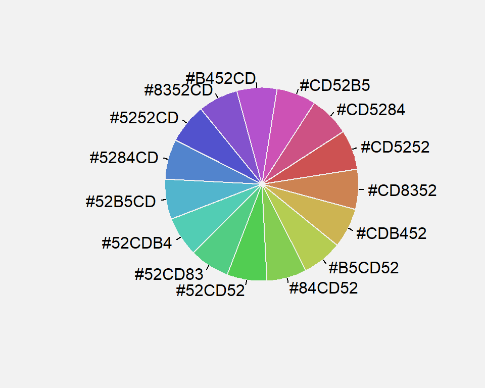

```
##  [1] "#B452CD" "#CD52B5" "#CD5284" "#CD5252" "#CD8352" "#CDB452" "#B5CD52" "#84CD52" "#52CD52"
## [10] "#52CD83" "#52CDB4" "#52B5CD" "#5284CD" "#5252CD" "#8352CD"
```

```r
library(colortools)

wheel("mediumorchid3", num = 15)
```

With this package you can create palettes based on color **complementarity** or **opposition**, creating harmonious or contrast-strong color schemes:

```r
analogous("mediumorchid3")
opposite("mediumorchid3")
splitComp("mediumorchid3")
triadic("mediumorchid3")
tetradic("mediumorchid3")
```

On the other hand, the function `pizza()` allows to visualize color palettes (colorRamps) in a wheel mode (use the **R color reference sheet** ):

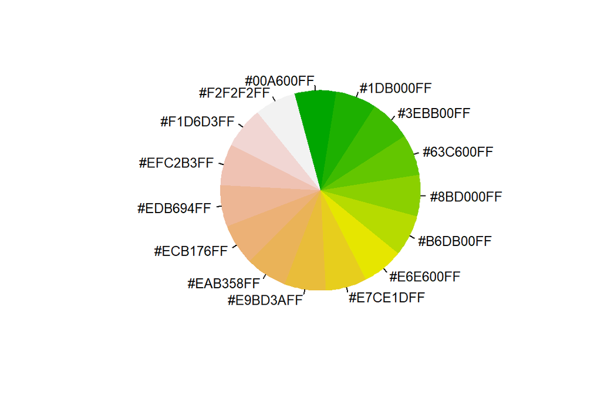

```r
pizza(terrain.colors(15), bg = "white")
```

colortools also provides an assortment of nice color palettes.

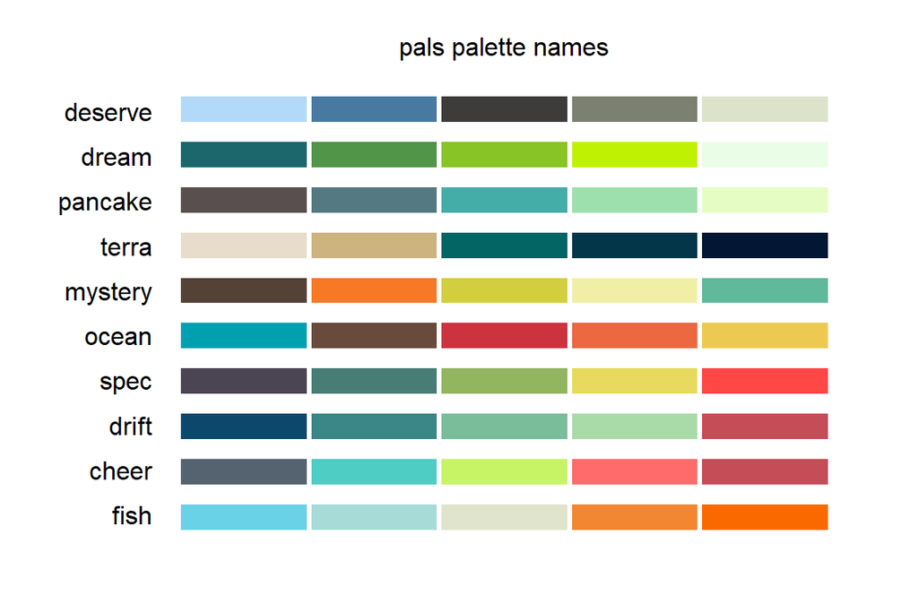

```r
pals()
```

```r
pals("terra")
```

```
## [1] "#E8DDCB" "#CDB380" "#036564" "#033649" "#031634"
```

### **ggpubr**:

> [OVERVIEW](https://rpkgs.datanovia.com/ggpubr/)

The `ggpubr` R package facilitates the creation of beautiful ggplot2-based graphs for researcher with non-advanced programming backgrounds.

```r
# Install
if(!require(devtools)) install.packages("devtools")
devtools::install_github("kassambara/ggpubr")
```

This package includes multiple functions simplifying the basic ggplot syntax, such as `ggboxplot()`, `ggscatter()` or `gghistogram()`.

```r
library(ggpubr)
```

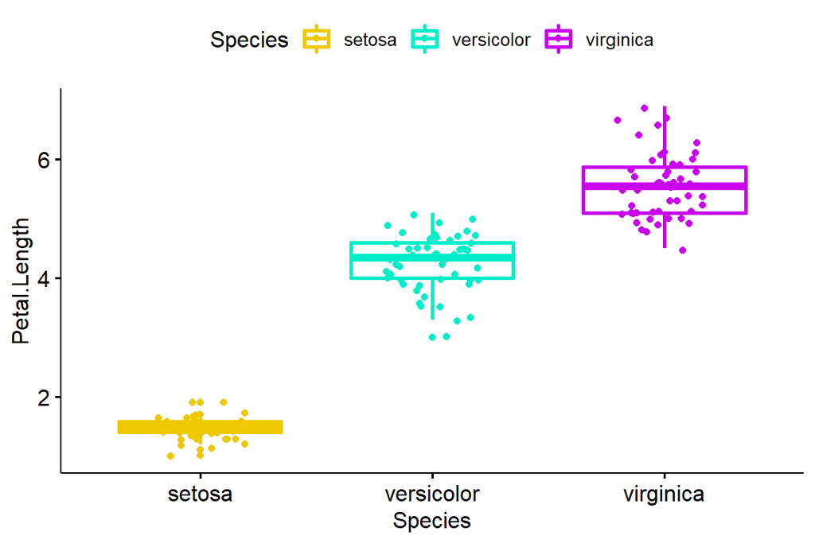

```r
pu_box <- ggboxplot(data = iris, x = "Species", y = "Petal.Length", color = "Species", size = 1,
                    palette =triadic("gold2", plot = F), add = "jitter")
pu_box
```

One of the most interesting applications is the **addition of p-values** comparing groups inside the plot. Allowed mean contrast methods are:

- `"t.test"` (parametric) and `"wilcox.test"` (non-parametric). Perform comparison between two groups of samples. If the grouping variable contains more than two levels, then a pairwise comparison is performed.
- `"anova"` (parametric) and `"kruskal.test"` (non-parametric). Perform one-way ANOVA test comparing multiple groups.

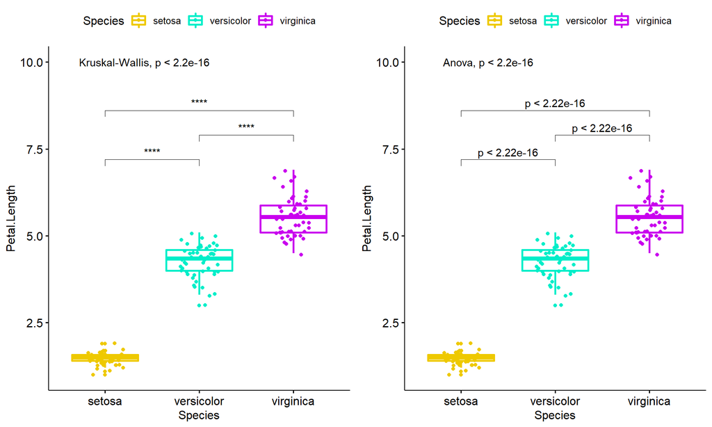

```r
my_comparisons <- list(c("setosa", "versicolor"), c("versicolor", "virginica"), c("setosa", "virginica"))

gridExtra::grid.arrange(
    pu_box + stat_compare_means(comparisons = my_comparisons, label = "p.signif") +
      stat_compare_means(label.y = 10),
    pu_box + stat_compare_means(comparisons = my_comparisons, method = "t.test", label = "p.format") +
      stat_compare_means(label.y = 10, method = "anova"),
    ncol = 2)
```

Other multiple utilities are available, such as ordered barplots…

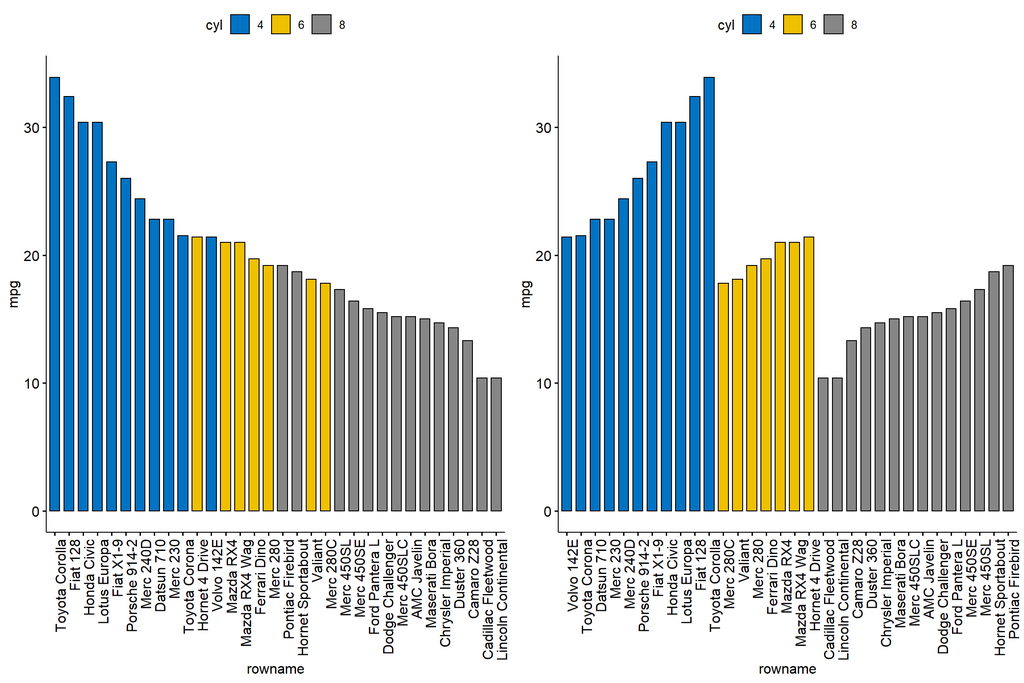

```r
data("mtcars")
mtcars <- mtcars %>% rownames_to_column()
mtcars$cyl <- as.factor(mtcars$cyl)

gridExtra::grid.arrange(
  ggbarplot(mtcars, x = "rowname", y = "mpg", fill = "cyl", palette = "jco", sort.val = "desc",
            sort.by.groups = FALSE, x.text.angle = 90),
  ggbarplot(mtcars, x = "rowname", y = "mpg", fill = "cyl", palette = "jco", sort.val = "asc",
            sort.by.groups = TRUE, x.text.angle = 90),
    ncol = 2)
```

Or another useful arrange function, `ggarrange()`:

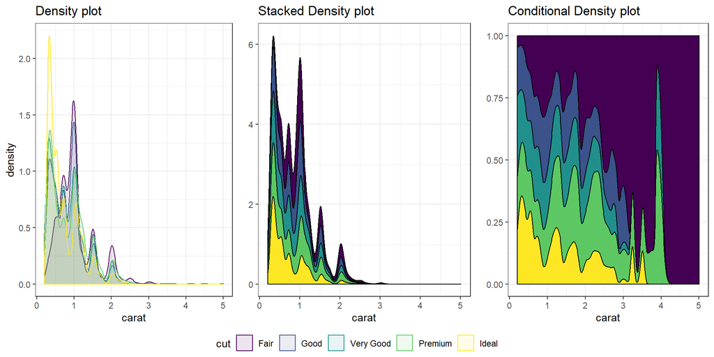

```r
ggarrange(diam0 + theme_bw(),
          diam1 + ylab(element_blank()) + theme_bw(),
          diam2 + ylab(element_blank()) + theme_bw(),
          ncol = 3, common.legend = TRUE, legend = "bottom")
```

### **ggrepel**:

> [EXAMPLES](https://cran.r-project.org/web/packages/ggrepel/vignettes/ggrepel.html)

This package provides 2 geom functions to repel **overlapping text labels** in ggplots.

```r
# Install
install.packages('ggrepel')
```

Lets plot a scatterplot with text, using our mtcars edited dataset:

```r
head(mtcars)
```

```
##             rowname  mpg cyl disp  hp drat    wt  qsec vs am gear carb
## 1         Mazda RX4 21.0   6  160 110 3.90 2.620 16.46  0  1    4    4
## 2     Mazda RX4 Wag 21.0   6  160 110 3.90 2.875 17.02  0  1    4    4
## 3        Datsun 710 22.8   4  108  93 3.85 2.320 18.61  1  1    4    1
## 4    Hornet 4 Drive 21.4   6  258 110 3.08 3.215 19.44  1  0    3    1
## 5 Hornet Sportabout 18.7   8  360 175 3.15 3.440 17.02  0  0    3    2
## 6           Valiant 18.1   6  225 105 2.76 3.460 20.22  1  0    3    1
```

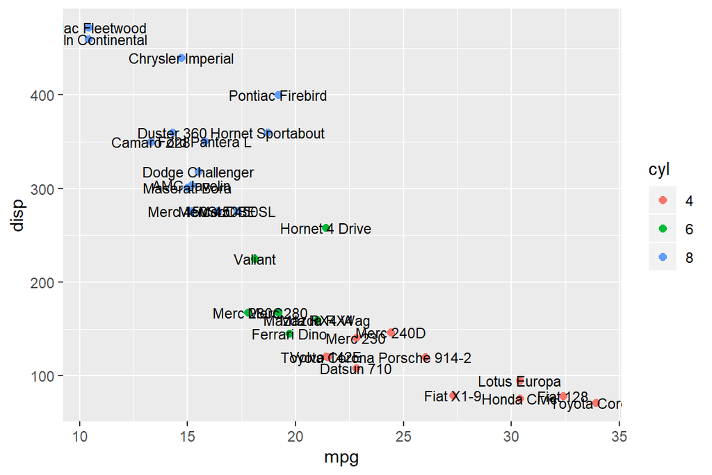

```r
ggplot(mtcars, aes(x = mpg, y = disp)) +
  geom_point(aes(col = cyl), size = 2) +
  geom_text(aes(label = rowname), size = 3)
```

Now, lets use the `geom_text_repel()` function:

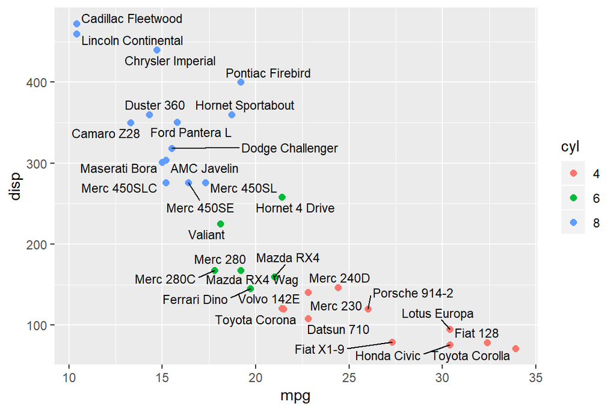

```r
library(ggrepel)

ggplot(mtcars, aes(x = mpg, y = disp)) +
  geom_point(aes(col = cyl), size = 2) +
  geom_text_repel(aes(label = rowname), size = 3)
```